# Project: No-show Appointments Dataset

- Introduction
- Data Wrangling
- Exploratory Data Analysis
- Conclusions

## Introduction

This dataset collects information from 100k medical appointments in Brazil and is focused on the question of whether or not patients show up for their appointment. A number of characteristics about the patient are included in each row.

- ‘ScheduledDay’ tells us on what day the patient set up their appointment.
- ‘Neighborhood’ indicates the location of the hospital.
- ‘Scholarship’ indicates whether or not the patient is enrolled in Brasilian welfare program Bolsa Família.
- Be careful about the encoding of the last column: it says ‘No’ if the patient showed up to their appointment, and ‘Yes’ if they did not show up.

*Goal*

- What factors are important for us to know in order to predict if a patient will show up for their scheduled appointment?

#### Importing Libraries

```python
import pandas as pd
import numpy as np
import matplotlib.pyplot as plt
import seaborn as sns
from sqlalchemy import create_engine
%matplotlib inline
sns.set_theme()
```

## Data Wrangling

### General Properties

```python
data = pd.read_csv('noshowappointments-kagglev2-may-2016.csv')
data.head()
```

|  | PatientId | AppointmentID | Gender | ScheduledDay | AppointmentDay | Age | Neighbourhood | Scholarship | Hipertension | Diabetes | Alcoholism | Handcap | SMS_received | No-show |
| --- | --- | --- | --- | --- | --- | --- | --- | --- | --- | --- | --- | --- | --- | --- |
| 0 | 2.987250e+13 | 5642903 | F | 2016-04-29T18:38:08Z | 2016-04-29T00:00:00Z | 62 | JARDIM DA PENHA | 0 | 1 | 0 | 0 | 0 | 0 | No |
| 1 | 5.589978e+14 | 5642503 | M | 2016-04-29T16:08:27Z | 2016-04-29T00:00:00Z | 56 | JARDIM DA PENHA | 0 | 0 | 0 | 0 | 0 | 0 | No |
| 2 | 4.262962e+12 | 5642549 | F | 2016-04-29T16:19:04Z | 2016-04-29T00:00:00Z | 62 | MATA DA PRAIA | 0 | 0 | 0 | 0 | 0 | 0 | No |
| 3 | 8.679512e+11 | 5642828 | F | 2016-04-29T17:29:31Z | 2016-04-29T00:00:00Z | 8 | PONTAL DE CAMBURI | 0 | 0 | 0 | 0 | 0 | 0 | No |
| 4 | 8.841186e+12 | 5642494 | F | 2016-04-29T16:07:23Z | 2016-04-29T00:00:00Z | 56 | JARDIM DA PENHA | 0 | 1 | 1 | 0 | 0 | 0 | No |

```python
df = data.copy()
df.head()
```

|  | PatientId | AppointmentID | Gender | ScheduledDay | AppointmentDay | Age | Neighbourhood | Scholarship | Hipertension | Diabetes | Alcoholism | Handcap | SMS_received | No-show |
| --- | --- | --- | --- | --- | --- | --- | --- | --- | --- | --- | --- | --- | --- | --- |
| 0 | 2.987250e+13 | 5642903 | F | 2016-04-29T18:38:08Z | 2016-04-29T00:00:00Z | 62 | JARDIM DA PENHA | 0 | 1 | 0 | 0 | 0 | 0 | No |
| 1 | 5.589978e+14 | 5642503 | M | 2016-04-29T16:08:27Z | 2016-04-29T00:00:00Z | 56 | JARDIM DA PENHA | 0 | 0 | 0 | 0 | 0 | 0 | No |
| 2 | 4.262962e+12 | 5642549 | F | 2016-04-29T16:19:04Z | 2016-04-29T00:00:00Z | 62 | MATA DA PRAIA | 0 | 0 | 0 | 0 | 0 | 0 | No |
| 3 | 8.679512e+11 | 5642828 | F | 2016-04-29T17:29:31Z | 2016-04-29T00:00:00Z | 8 | PONTAL DE CAMBURI | 0 | 0 | 0 | 0 | 0 | 0 | No |
| 4 | 8.841186e+12 | 5642494 | F | 2016-04-29T16:07:23Z | 2016-04-29T00:00:00Z | 56 | JARDIM DA PENHA | 0 | 1 | 1 | 0 | 0 | 0 | No |

```python
df.shape
```

```
(110527, 14)
```

```python
df.describe()
```

|  | PatientId | AppointmentID | Age | Scholarship | Hipertension | Diabetes | Alcoholism | Handcap | SMS_received |
| --- | --- | --- | --- | --- | --- | --- | --- | --- | --- |
| count | 1.105270e+05 | 1.105270e+05 | 110527.000000 | 110527.000000 | 110527.000000 | 110527.000000 | 110527.000000 | 110527.000000 | 110527.000000 |
| mean | 1.474963e+14 | 5.675305e+06 | 37.088874 | 0.098266 | 0.197246 | 0.071865 | 0.030400 | 0.022248 | 0.321026 |
| std | 2.560949e+14 | 7.129575e+04 | 23.110205 | 0.297675 | 0.397921 | 0.258265 | 0.171686 | 0.161543 | 0.466873 |
| min | 3.921784e+04 | 5.030230e+06 | -1.000000 | 0.000000 | 0.000000 | 0.000000 | 0.000000 | 0.000000 | 0.000000 |
| 25% | 4.172614e+12 | 5.640286e+06 | 18.000000 | 0.000000 | 0.000000 | 0.000000 | 0.000000 | 0.000000 | 0.000000 |
| 50% | 3.173184e+13 | 5.680573e+06 | 37.000000 | 0.000000 | 0.000000 | 0.000000 | 0.000000 | 0.000000 | 0.000000 |
| 75% | 9.439172e+13 | 5.725524e+06 | 55.000000 | 0.000000 | 0.000000 | 0.000000 | 0.000000 | 0.000000 | 1.000000 |
| max | 9.999816e+14 | 5.790484e+06 | 115.000000 | 1.000000 | 1.000000 | 1.000000 | 1.000000 | 4.000000 | 1.000000 |

```python
df.info()
```

```
<class 'pandas.core.frame.DataFrame'>
RangeIndex: 110527 entries, 0 to 110526
Data columns (total 14 columns):
 #   Column          Non-Null Count   Dtype
---  ------          --------------   -----
 0   PatientId       110527 non-null  float64
 1   AppointmentID   110527 non-null  int64
 2   Gender          110527 non-null  object
 3   ScheduledDay    110527 non-null  object
 4   AppointmentDay  110527 non-null  object
 5   Age             110527 non-null  int64
 6   Neighbourhood   110527 non-null  object
 7   Scholarship     110527 non-null  int64
 8   Hipertension    110527 non-null  int64
 9   Diabetes        110527 non-null  int64
 10  Alcoholism      110527 non-null  int64
 11  Handcap         110527 non-null  int64
 12  SMS_received    110527 non-null  int64
 13  No-show         110527 non-null  object
dtypes: float64(1), int64(8), object(5)
memory usage: 11.8+ MB
```

```python
df.nunique()
```

```
PatientId          62299
AppointmentID     110527
Gender                 2
ScheduledDay      103549
AppointmentDay        27
Age                  104
Neighbourhood         81
Scholarship            2
Hipertension           2
Diabetes               2
Alcoholism             2
Handcap                5
SMS_received           2
No-show                2
dtype: int64
```

```python
df['Handcap'].unique()
```

```
array([0, 1, 2, 3, 4], dtype=int64)
```

```python
df.duplicated().sum()
```

```
0
```

```python
df['Age'].unique()
```

```
array([ 62,  56,   8,  76,  23,  39,  21,  19,  30,  29,  22,  28,  54,
        15,  50,  40,  46,   4,  13,  65,  45,  51,  32,  12,  61,  38,
        79,  18,  63,  64,  85,  59,  55,  71,  49,  78,  31,  58,  27,
         6,   2,  11,   7,   0,   3,   1,  69,  68,  60,  67,  36,  10,
        35,  20,  26,  34,  33,  16,  42,   5,  47,  17,  41,  44,  37,
        24,  66,  77,  81,  70,  53,  75,  73,  52,  74,  43,  89,  57,
        14,   9,  48,  83,  72,  25,  80,  87,  88,  84,  82,  90,  94,
        86,  91,  98,  92,  96,  93,  95,  97, 102, 115, 100,  99,  -1],
      dtype=int64)
```

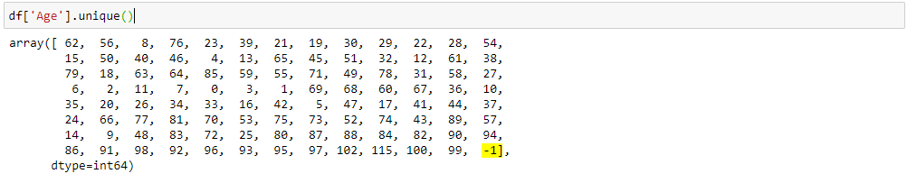

Age can not be -1

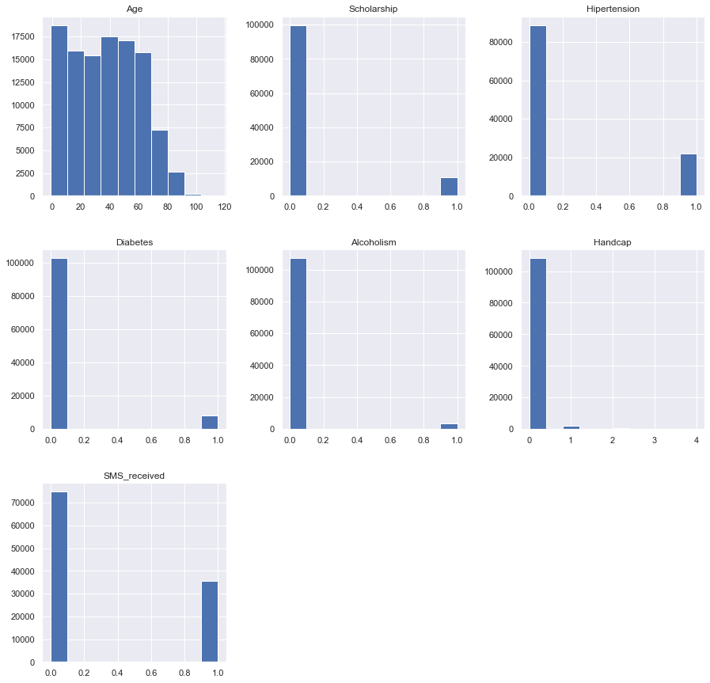

```python
df.drop(['PatientId', 'AppointmentID'], axis=1).hist(figsize=(15,15));
```

### Data Cleaning

Here I will clean the dataset and try to make columns more understandable for reader

- Removing 'Age' outliers
- Recorrect Columns Names (Hipertension, Handcap, Scholarship, Diabetes, Neighborhood, No-show) to (Has Hypertension, Handicap Level, Family Allowance, Has Diabetes, Hospital Location, Attendance)
- Convert columns (ScheduledDay, AppointmentDay) into datetime.
- Drop Columns (PatientId, AppointmentID)
- Rename Genders

#### Removing 'Age' Outliers

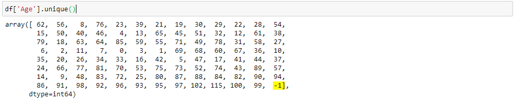

Age can not be -1

```python
df.drop(df.index[df['Age'] < 0], inplace=True)
```

```python
df.shape
```

```
(110526, 14)
```

```python
df[df['Age'] < 0]
```

|  | PatientId | AppointmentID | Gender | ScheduledDay | AppointmentDay | Age | Neighbourhood | Scholarship | Hipertension | Diabetes | Alcoholism | Handcap | SMS_received | No-show |
| --- | --- | --- | --- | --- | --- | --- | --- | --- | --- | --- | --- | --- | --- | --- |

#### Dropping Non-necessary Columns

```python
df.drop(['PatientId', 'AppointmentID'], axis=1, inplace=True)
```

```python
df.columns
```

```
Index(['Gender', 'ScheduledDay', 'AppointmentDay', 'Age', 'Neighbourhood',
       'Scholarship', 'Hipertension', 'Diabetes', 'Alcoholism', 'Handcap',
       'SMS_received', 'No-show'],
      dtype='object')
```

#### Correcting Columns' Names

```python
df.columns = ['Gender', 'ScheduledDay', 'AppointmentDay', 'Age', 'Hospital Location',
       'Family Allowance', 'Has Hypertension', 'Has Diabetes', 'Alcoholism', 'Handicap Level',
       'SMS_received', 'Attendance']
```

```python
df.columns
```

```
Index(['Gender', 'ScheduledDay', 'AppointmentDay', 'Age', 'Hospital Location',
       'Family Allowance', 'Has Hypertension', 'Has Diabetes', 'Alcoholism',
       'Handicap Level', 'SMS_received', 'Attendance'],
      dtype='object')
```

#### Renaming Gender Categories

```python
df.loc[df['Gender'] == 'F', 'Gender'] = 'Female'
df.loc[df['Gender'] == 'M', 'Gender'] = 'Male'
```

```python
df['Gender'].value_counts()
```

```
Female    71839
Male      38687
Name: Gender, dtype: int64
```

#### Renaming Attendance Categories

```python
df.loc[df['Attendance'] == 'No', 'Attendance'] = 'Attended'
df.loc[df['Attendance'] == 'Yes', 'Attendance'] = 'Missed Appointment'
```

```python
df['Attendance'].value_counts()
```

```
Attended              88207
Missed Appointment    22319
Name: Attendance, dtype: int64
```

#### Converting columns (ScheduledDay, AppointmentDay) into datetime

```python
df['ScheduledDay'] = pd.to_datetime(df['ScheduledDay'])
df['AppointmentDay'] = pd.to_datetime(df['AppointmentDay'])
```

#### Extracting day name from 'AppointmentDay)' column

```python
df['Appointment_WeekDay'] = df['AppointmentDay'].dt.day_name()
```

```python
df.info()
```

```
<class 'pandas.core.frame.DataFrame'>
Int64Index: 110526 entries, 0 to 110526
Data columns (total 13 columns):
 #   Column               Non-Null Count   Dtype
---  ------               --------------   -----
 0   Gender               110526 non-null  object
 1   ScheduledDay         110526 non-null  datetime64[ns, UTC]
 2   AppointmentDay       110526 non-null  datetime64[ns, UTC]
 3   Age                  110526 non-null  int64
 4   Hospital Location    110526 non-null  object
 5   Family Allowance     110526 non-null  int64
 6   Has Hypertension     110526 non-null  int64
 7   Has Diabetes         110526 non-null  int64
 8   Alcoholism           110526 non-null  int64
 9   Handicap Level       110526 non-null  int64
 10  SMS_received         110526 non-null  int64
 11  Attendance           110526 non-null  object
 12  Appointment_WeekDay  110526 non-null  object
dtypes: datetime64[ns, UTC](2), int64(7), object(4)
memory usage: 11.8+ MB
```

```python
df.head()
```

|  | Gender | ScheduledDay | AppointmentDay | Age | Hospital Location | Family Allowance | Has Hypertension | Has Diabetes | Alcoholism | Handicap Level | SMS_received | Attendance | Appointment_WeekDay |
| --- | --- | --- | --- | --- | --- | --- | --- | --- | --- | --- | --- | --- | --- |
| 0 | Female | 2016-04-29 18:38:08+00:00 | 2016-04-29 00:00:00+00:00 | 62 | JARDIM DA PENHA | 0 | 1 | 0 | 0 | 0 | 0 | Attended | Friday |
| 1 | Male | 2016-04-29 16:08:27+00:00 | 2016-04-29 00:00:00+00:00 | 56 | JARDIM DA PENHA | 0 | 0 | 0 | 0 | 0 | 0 | Attended | Friday |
| 2 | Female | 2016-04-29 16:19:04+00:00 | 2016-04-29 00:00:00+00:00 | 62 | MATA DA PRAIA | 0 | 0 | 0 | 0 | 0 | 0 | Attended | Friday |
| 3 | Female | 2016-04-29 17:29:31+00:00 | 2016-04-29 00:00:00+00:00 | 8 | PONTAL DE CAMBURI | 0 | 0 | 0 | 0 | 0 | 0 | Attended | Friday |
| 4 | Female | 2016-04-29 16:07:23+00:00 | 2016-04-29 00:00:00+00:00 | 56 | JARDIM DA PENHA | 0 | 1 | 1 | 0 | 0 | 0 | Attended | Friday |

## Exploratory Data Analysis

```python
font_size1 = 16
font_size2 = 12
```

### What is the Highest Gender of Patients?

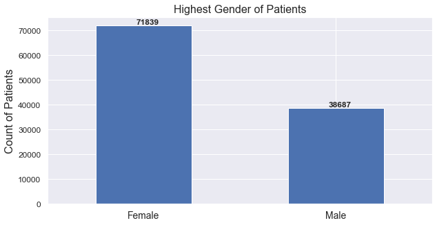

```python
df['Gender'].value_counts().plot(kind='bar', figsize=(10,5));df['Gender'].value_counts()


plt.ylabel('Count of Patients', fontsize=font_size1);
plt.title('Highest Gender of Patients', fontsize=font_size1);
plt.xticks(fontsize= font_size2+2, rotation='horizontal');
plt.yticks(fontsize= font_size2)

for num, value in enumerate(df['Gender'].value_counts()):
    plt.text(num-0.04, value+500, str(value), fontweight='bold');
```

### What is the percentage of Attendance?

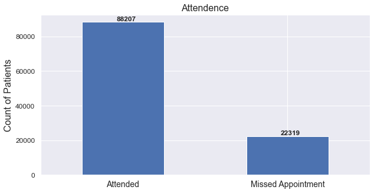

```python
df['Attendance'].value_counts().plot(kind='bar', figsize=(10,5));

plt.ylabel('Count of Patients', fontsize=font_size1);
plt.title('Attendence', fontsize=font_size1);
plt.xticks(fontsize= font_size2+2, rotation='horizontal');
plt.yticks(fontsize= font_size2)

for num, value in enumerate(df['Attendance'].value_counts()):
    plt.text(num-0.04, value+800, str(value), fontweight='bold');
```

### What are the Highest Hospitals has attendancies?

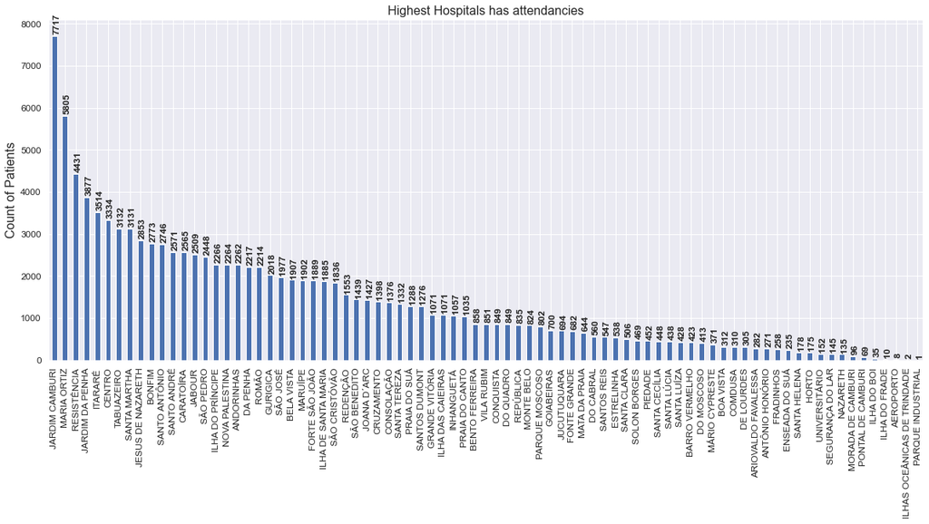

```python
df['Hospital Location'].value_counts().plot(kind='bar',figsize=(20,8));

plt.ylabel('Count of Patients', fontsize=font_size1);
plt.title('Highest Hospitals has attendancies', fontsize=font_size1);
plt.xticks(fontsize= font_size2, rotation='vertical');
plt.yticks(fontsize= font_size2)

for num, value in enumerate(df['Hospital Location'].value_counts()):
    plt.text(num-0.15, value+80, str(value), fontweight='bold', rotation='vertical');
```

### What is the relation between Attendance and Patients who recieved an SMS for the appointment?

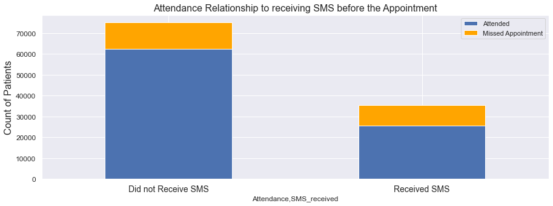

```python
SMS_Attended = df[df['Attendance']=='Attended'].groupby('Attendance')['SMS_received'].value_counts()
SMS_Attended.plot(kind='bar', figsize=(15,5));
SMS_Missed = df[df['Attendance']=='Missed Appointment'].groupby('Attendance')['SMS_received'].value_counts()
SMS_Missed.plot(kind='bar', figsize=(15,5), bottom=SMS_Attended, color='orange');

x_ticks = ['Did not Receive SMS', 'Received SMS']
plt.ylabel('Count of Patients', fontsize=font_size1);
plt.title('Attendance Relationship to receiving SMS before the Appointment', fontsize=font_size1);
plt.xticks(fontsize= font_size2+2, rotation='horizontal', ticks=[0,1], labels=x_ticks);
plt.yticks(fontsize= font_size2)
plt.legend(['Attended', 'Missed Appointment']);
```

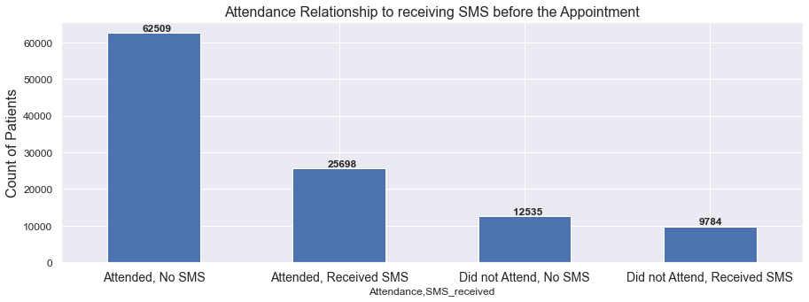

```python
df.groupby('Attendance')['SMS_received'].value_counts().plot(kind='bar', figsize=(15,5));

x_ticks = ['Attended, No SMS', 'Attended, Received SMS', 'Did not Attend, No SMS', 'Did not Attend, Received SMS']
plt.ylabel('Count of Patients', fontsize=font_size1);
plt.title('Attendance Relationship to receiving SMS before the Appointment', fontsize=font_size1);
plt.xticks(fontsize= font_size2+2, rotation='horizontal', ticks=[0,1,2,3], labels=x_ticks);
plt.yticks(fontsize= font_size2);

for num, value in enumerate(df.groupby('Attendance')['SMS_received'].value_counts()):
        plt.text(num-0.06, value+500, str(value), fontweight='bold');
```

### What is the relation between Attendance and Handicap Level?

```
Attendance  Handicap Level
Attended    0                 86373
            1                  1676
            2                   146
            3                    10
            4                     2
Name: Handicap Level, dtype: int64

 Attendance          Handicap Level
Missed Appointment  0                 21912
                    1                   366
                    2                    37
                    3                     3
                    4                     1
Name: Handicap Level, dtype: int64
```

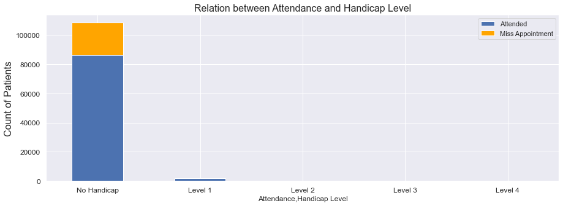

```python
Handicap_Attended = df[df['Attendance']=='Attended'].groupby('Attendance')['Handicap Level'].value_counts()
Handicap_Attended.plot(kind='bar', figsize=(15,5));
Handicap_Missed = df[df['Attendance']=='Missed Appointment'].groupby('Attendance')['Handicap Level'].value_counts()
Handicap_Missed.plot(kind='bar', figsize=(15,5), bottom=Handicap_Attended, color='orange');

x_ticks = ['No Handicap', 'Level 1', 'Level 2', 'Level 3', 'Level 4']
plt.ylabel('Count of Patients', fontsize=font_size1);
plt.title('Relation between Attendance and Handicap Level', fontsize=font_size1);
plt.xticks(fontsize= font_size2, rotation='horizontal', labels=x_ticks, ticks=[0,1,2,3,4]);
plt.yticks(fontsize= font_size2);
plt.legend(['Attended', 'Miss Appointment']);

print(Handicap_Attended,'\n'*2, Handicap_Missed)
```

Here we will find that patients who have a handicap have a small chance to miss their appointment, as the percentage of patients who missed their appointment with a handicap is less than those healthy ones, 1.8% of all patients have a handicap and missed the appintment, but 2% has attended.

### What is the relation between Attendance and Alcoholism?

```
Attendance  Alcoholism
Attended    0             85524
            1              2683
Name: Alcoholism, dtype: int64

 Attendance          Alcoholism
Missed Appointment  0             21642
                    1               677
Name: Alcoholism, dtype: int64
```

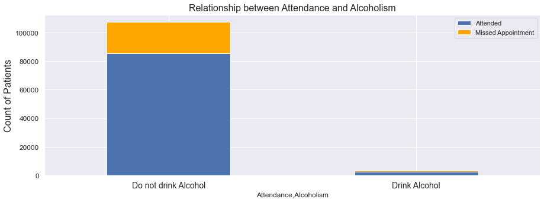

```python
Alcoholism_Attended = df[df['Attendance']=='Attended'].groupby('Attendance')['Alcoholism'].value_counts()
Alcoholism_Attended.plot(kind='bar', figsize=(15,5));
Alcoholism_Missed = df[df['Attendance']=='Missed Appointment'].groupby('Attendance')['Alcoholism'].value_counts()
Alcoholism_Missed.plot(kind='bar', figsize=(15,5), bottom=Alcoholism_Attended, color='orange');

x_ticks = ['Do not drink Alcohol', 'Drink Alcohol']
plt.ylabel('Count of Patients', fontsize=font_size1);
plt.title('Relationship between Attendance and Alcoholism', fontsize=font_size1);
plt.xticks(fontsize= font_size2+2, rotation='horizontal', ticks=[0,1], labels=x_ticks);
plt.yticks(fontsize= font_size2)
plt.legend(['Attended', 'Missed Appointment']);

print(Alcoholism_Attended,'\n'*2, Alcoholism_Missed)
```

### What is the relation between Attendance and Patients who has Diabetes?

```
Attendance  Has Diabetes
Attended    0               81694
            1                6513
Name: Has Diabetes, dtype: int64

 Attendance          Has Diabetes
Missed Appointment  0               20889
                    1                1430
Name: Has Diabetes, dtype: int64
```

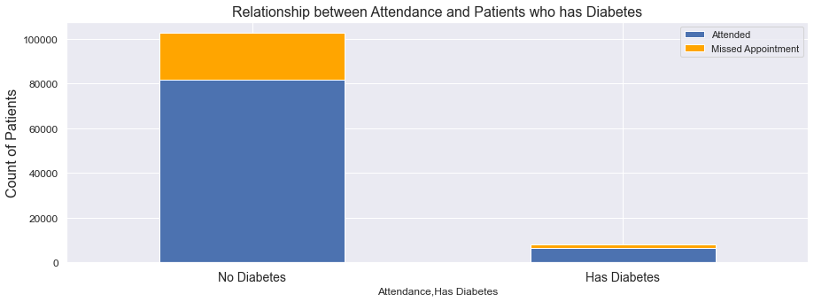

```python
Diabetes_Attended = df[df['Attendance']=='Attended'].groupby('Attendance')['Has Diabetes'].value_counts()
Diabetes_Attended.plot(kind='bar', figsize=(15,5));
Diabetes_Missed = df[df['Attendance']=='Missed Appointment'].groupby('Attendance')['Has Diabetes'].value_counts()
Diabetes_Missed.plot(kind='bar', figsize=(15,5), bottom=Diabetes_Attended, color='orange');

x_ticks = ['No Diabetes', 'Has Diabetes']
plt.ylabel('Count of Patients', fontsize=font_size1);
plt.title('Relationship between Attendance and Patients who has Diabetes', fontsize=font_size1);
plt.xticks(fontsize= font_size2+2, rotation='horizontal', ticks=[0,1], labels=x_ticks);
plt.yticks(fontsize= font_size2)
plt.legend(['Attended', 'Missed Appointment']);

print(Diabetes_Attended,'\n'*2, Diabetes_Missed)
```

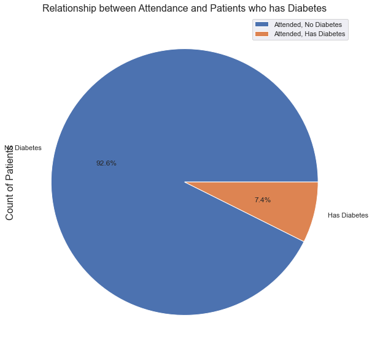

```python
Diabetes_Attended = df[df['Attendance']=='Attended'].groupby('Attendance')['Has Diabetes'].value_counts()
Diabetes_Attended.plot(kind='pie', figsize=(10,10),autopct='%1.1f%%',labels=['No Diabetes', 'Has Diabetes']);

plt.ylabel('Count of Patients', fontsize=font_size1);
plt.title('Relationship between Attendance and Patients who has Diabetes', fontsize=font_size1);
plt.xticks(fontsize= font_size2+2, rotation='horizontal');
plt.yticks(fontsize= font_size2)
plt.legend(['Attended, No Diabetes', 'Attended, Has Diabetes']);
```

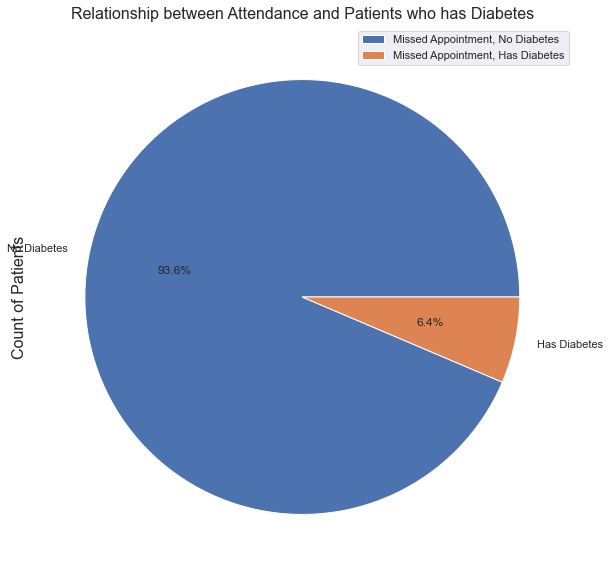

```python
Diabetes_Missed = df[df['Attendance']=='Missed Appointment'].groupby('Attendance')['Has Diabetes'].value_counts()
Diabetes_Missed.plot(kind='pie', figsize=(10,10),autopct='%1.1f%%',labels=['No Diabetes', 'Has Diabetes']);

plt.ylabel('Count of Patients', fontsize=font_size1);
plt.title('Relationship between Attendance and Patients who has Diabetes', fontsize=font_size1);
plt.xticks(fontsize= font_size2+2, rotation='horizontal');
plt.yticks(fontsize= font_size2)
plt.legend(['Missed Appointment, No Diabetes', 'Missed Appointment, Has Diabetes']);
```

Here we will find that patients who have Diabetes have a small chance to miss his appointment, as the percentage of patients who missed their appointment with Diabetes is less than those healthy ones by 1%.

### What is the relation between Attendance and Patients who has Hypertension?

```
Attendance  Has Hypertension
Attended    0                   70178
            1                   18029
Name: Has Hypertension, dtype: int64

 Attendance          Has Hypertension
Missed Appointment  0                   18547
                    1                    3772
Name: Has Hypertension, dtype: int64
```

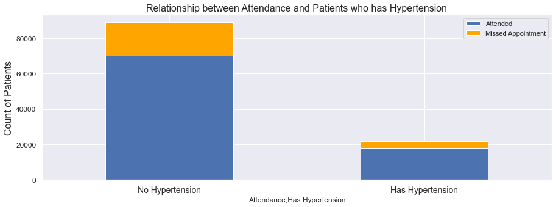

```python
Hypertension_Attended = df[df['Attendance']=='Attended'].groupby('Attendance')['Has Hypertension'].value_counts()
Hypertension_Attended.plot(kind='bar', figsize=(15,5));
Hypertension_Missed = df[df['Attendance']=='Missed Appointment'].groupby('Attendance')['Has Hypertension'].value_counts()
Hypertension_Missed.plot(kind='bar', figsize=(15,5), bottom=Hypertension_Attended, color='orange');

x_ticks = ['No Hypertension', 'Has Hypertension']
plt.ylabel('Count of Patients', fontsize=font_size1);
plt.title('Relationship between Attendance and Patients who has Hypertension', fontsize=font_size1);
plt.xticks(fontsize= font_size2+2, rotation='horizontal', ticks=[0,1], labels=x_ticks);
plt.yticks(fontsize= font_size2)
plt.legend(['Attended', 'Missed Appointment']);

print(Hypertension_Attended,'\n'*2, Hypertension_Missed)
```

```
Attendance  Has Hypertension
Attended    0                   70178
            1                   18029
Name: Has Hypertension, dtype: int64
```

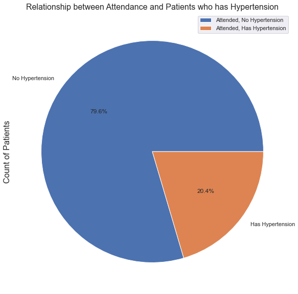

```python
Hypertension_Attended = df[df['Attendance']=='Attended'].groupby('Attendance')['Has Hypertension'].value_counts()
Hypertension_Attended.plot(kind='pie', figsize=(10,10),autopct='%1.1f%%', labels=['No Hypertension', 'Has Hypertension']);

plt.ylabel('Count of Patients', fontsize=font_size1);
plt.title('Relationship between Attendance and Patients who has Hypertension', fontsize=font_size1);
plt.xticks(fontsize= font_size2+2, rotation='horizontal');
plt.yticks(fontsize= font_size2)
plt.legend(['Attended, No Hypertension', 'Attended, Has Hypertension']);

Hypertension_Attended
```

```
Attendance          Has Hypertension
Missed Appointment  0                   18547
                    1                    3772
Name: Has Hypertension, dtype: int64
```

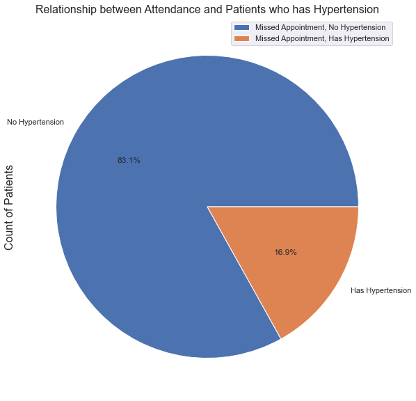

```python
Hypertension_Missed = df[df['Attendance']=='Missed Appointment'].groupby('Attendance')['Has Hypertension'].value_counts()
Hypertension_Missed.plot(kind='pie', figsize=(10,10),autopct='%1.1f%%', labels=['No Hypertension', 'Has Hypertension']);


plt.ylabel('Count of Patients', fontsize=font_size1);
plt.title('Relationship between Attendance and Patients who has Hypertension', fontsize=font_size1);
plt.xticks(fontsize= font_size2+2, rotation='horizontal');
plt.yticks(fontsize= font_size2)
plt.legend(['Missed Appointment, No Hypertension', 'Missed Appointment, Has Hypertension']);

Hypertension_Missed
```

Here we will find that patients who have hypertension have a small chance to miss his appointment, as the percentage of patients who miss their appointment with hypertension is less than those healthy ones by 3.5%.

### What is the relation between Attendance and Patients who has Family Allowance (Bosla Familia)?

```
Attendance  Family Allowance
Attended    0                   79924
            1                    8283
Name: Family Allowance, dtype: int64

 Attendance          Family Allowance
Missed Appointment  0                   19741
                    1                    2578
Name: Family Allowance, dtype: int64
```

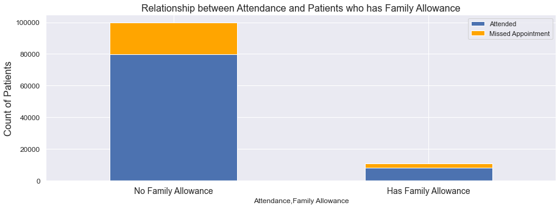

```python
Allowance_Attended = df[df['Attendance']=='Attended'].groupby('Attendance')['Family Allowance'].value_counts()
Allowance_Attended.plot(kind='bar', figsize=(15,5));
Allowance_Missed = df[df['Attendance']=='Missed Appointment'].groupby('Attendance')['Family Allowance'].value_counts()
Allowance_Missed.plot(kind='bar', figsize=(15,5), bottom=Allowance_Attended, color='orange');

x_ticks = ['No Family Allowance', 'Has Family Allowance']
plt.ylabel('Count of Patients', fontsize=font_size1);
plt.title('Relationship between Attendance and Patients who has Family Allowance', fontsize=font_size1);
plt.xticks(fontsize= font_size2+2, rotation='horizontal', ticks=[0,1], labels=x_ticks);
plt.yticks(fontsize= font_size2)
plt.legend(['Attended', 'Missed Appointment']);

print(Allowance_Attended,'\n'*2, Allowance_Missed)
```

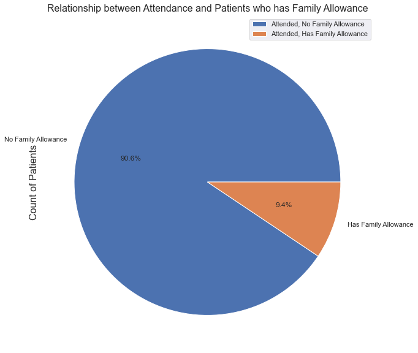

```python
Allowance_Attended = df[df['Attendance']=='Attended'].groupby('Attendance')['Family Allowance'].value_counts()
Allowance_Attended.plot(kind='pie', figsize=(10,10),labels=['No Family Allowance', 'Has Family Allowance'], autopct='%1.1f%%');

plt.ylabel('Count of Patients', fontsize=font_size1);
plt.title('Relationship between Attendance and Patients who has Family Allowance', fontsize=font_size1);
plt.xticks(fontsize= font_size2+2, rotation='horizontal');
plt.yticks(fontsize= font_size2)
plt.legend(['Attended, No Family Allowance', 'Attended, Has Family Allowance']);
```

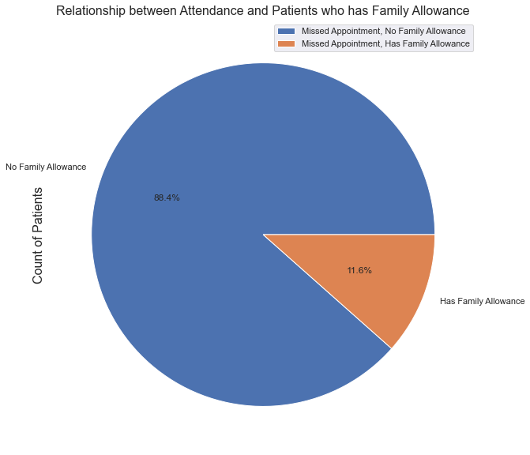

```python
Allowance_Missed = df[df['Attendance']=='Missed Appointment'].groupby('Attendance')['Family Allowance'].value_counts()
Allowance_Missed.plot(kind='pie', figsize=(10,10),labels=['No Family Allowance', 'Has Family Allowance'], autopct='%1.1f%%');

plt.ylabel('Count of Patients', fontsize=font_size1);
plt.title('Relationship between Attendance and Patients who has Family Allowance', fontsize=font_size1);
plt.xticks(fontsize= font_size2+2, rotation='horizontal');
plt.yticks(fontsize= font_size2)
plt.legend(['Missed Appointment, No Family Allowance', 'Missed Appointment, Has Family Allowance']);
```

Here we will find that patients who have family allowance have a higher chance to miss their appointment, as the percentage of patients who missed their appointment is more than those who attended by 2.2%.

### What is the relation between Attendance and Week-day (Bussiness days & Weekends)?

```
Appointment_WeekDay  Attendance
Friday               Attended      14982
Monday               Attended      18024
Saturday             Attended         30
Thursday             Attended      13909
Tuesday              Attended      20488
Wednesday            Attended      20774
Name: Attendance, dtype: int64

 Appointment_WeekDay  Attendance
Friday               Missed Appointment    4037
Monday               Missed Appointment    4690
Saturday             Missed Appointment       9
Thursday             Missed Appointment    3338
Tuesday              Missed Appointment    5152
Wednesday            Missed Appointment    5093
Name: Attendance, dtype: int64
```

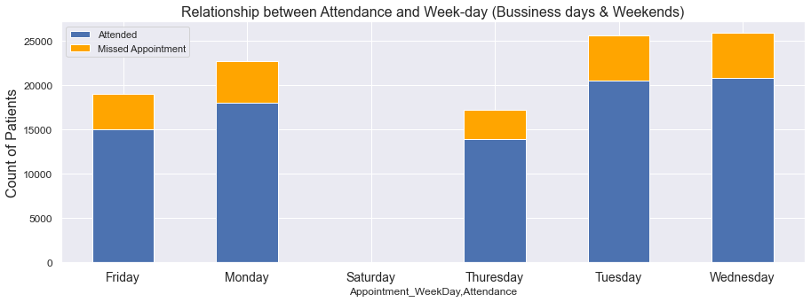

```python
Day_Attended = df[df['Attendance']=='Attended'].groupby('Appointment_WeekDay')['Attendance'].value_counts()
Day_Attended.plot(kind='bar', figsize=(15,5));
Day_Missed = df[df['Attendance']=='Missed Appointment'].groupby('Appointment_WeekDay')['Attendance'].value_counts()
Day_Missed.plot(kind='bar', figsize=(15,5), bottom=Day_Attended, color='orange');

x_ticks = ['Friday', 'Monday', 'Saturday','Thuresday','Tuesday','Wednesday']
plt.ylabel('Count of Patients', fontsize=font_size1);
plt.title('Relationship between Attendance and Week-day (Bussiness days & Weekends)', fontsize=font_size1);
plt.xticks(fontsize= font_size2+2, rotation='horizontal', ticks=[0,1,2,3,4,5], labels=x_ticks);
plt.yticks(fontsize= font_size2)
plt.legend(['Attended', 'Missed Appointment']);

print(Day_Attended, '\n'*2, Day_Missed)
```

Here we will find that work days had attendance more than weekends, and hospitals has no appointments at Sundays. The highest day of appointments is Wednesday by 25867 appointments followed by Tuesday by 25640 appointments, and the least one is Saturday with total 39 appointments.

### What is the relation among Age, Gender, and Attendence?

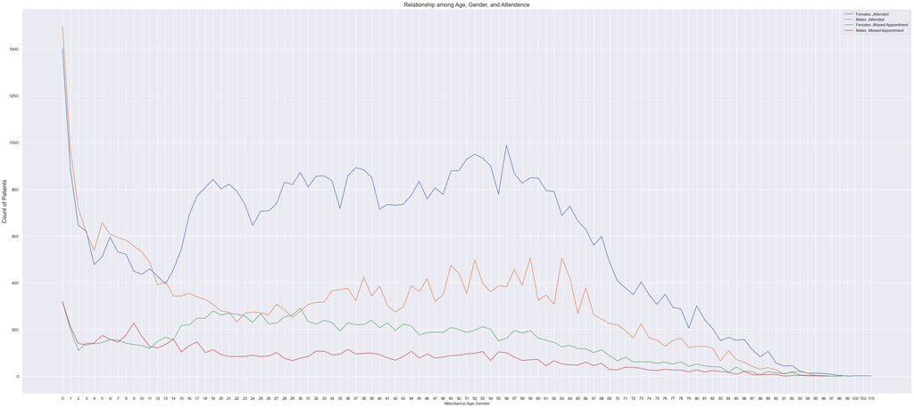

```python
FAA = df[df['Gender']=='Female'][df[df['Gender']=='Female']['Attendance'] == 'Attended'].groupby(['Attendance','Age'])['Gender'].value_counts()
FAA.plot(figsize=(45,20));
MAA = df[df['Gender']=='Male'][df[df['Gender']=='Male']['Attendance'] == 'Attended'].groupby(['Attendance','Age'])['Gender'].value_counts()
MAA.plot(figsize=(45,20));

FMA = df[df['Gender']=='Female'][df[df['Gender']=='Female']['Attendance'] == 'Missed Appointment'].groupby(['Attendance','Age'])['Gender'].value_counts()
FMA.plot(figsize=(45,20));
MMA = df[df['Gender']=='Male'][df[df['Gender']=='Male']['Attendance'] == 'Missed Appointment'].groupby(['Attendance','Age'])['Gender'].value_counts()
MMA.plot(figsize=(45,20));

x = []
for i in range(len(FAA.index)):
    Attendance,Age,Gender = FAA.index[i]
    x.append(Age)

x_ticks = x
plt.ylabel('Count of Patients', fontsize=font_size1);
plt.title('Relationship among Age, Gender, and Attendence', fontsize=font_size1);
plt.xticks(fontsize= font_size2, rotation='horizontal', labels=x_ticks, ticks=np.arange(len(x)));
plt.yticks(fontsize= font_size2);
plt.legend(['Females ,Attended', 'Males ,Attended', 'Females ,Missed Appointment', 'Males ,Missed Appointment']);
```

### What is the relation among Age, Family Allowance, and Attendence?

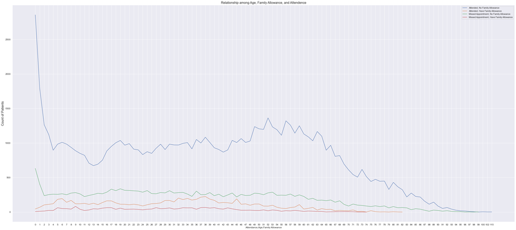

```python
FAA = df[df['Family Allowance']==0][df[df['Family Allowance']==0]['Attendance'] == 'Attended'].groupby(['Attendance','Age'])['Family Allowance'].value_counts()
FAA.plot(figsize=(45,20));
MAA = df[df['Family Allowance']==1][df[df['Family Allowance']==1]['Attendance'] == 'Attended'].groupby(['Attendance','Age'])['Family Allowance'].value_counts()
MAA.plot(figsize=(45,20));

FMA = df[df['Family Allowance']==0][df[df['Family Allowance']==0]['Attendance'] == 'Missed Appointment'].groupby(['Attendance','Age'])['Family Allowance'].value_counts()
FMA.plot(figsize=(45,20));

MMA = df[df['Family Allowance']==1][df[df['Family Allowance']==1]['Attendance'] == 'Missed Appointment'].groupby(['Attendance','Age'])['Family Allowance'].value_counts()
MMA.plot(figsize=(45,20));

x = []
for i in range(len(FAA.index)):
    Attendance,Age,Family_Allowance = FAA.index[i]
    x.append(Age)

x_ticks = x
plt.ylabel('Count of Patients', fontsize=font_size1);
plt.title('Relationship among Age, Family Allowance, and Attendence', fontsize=font_size1);
plt.xticks(fontsize= font_size2, rotation='horizontal', labels=x_ticks, ticks=np.arange(len(x)));
plt.yticks(fontsize= font_size2);
plt.legend(['Attended, No Family Allowance', 'Attended, Have Family Allowance', 'Missed Appointment, No Family Allowance', 'Missed Appointment, Have Family Allowance']);
```

### What is the relation among Family Allowance, Gender, and Attendence?

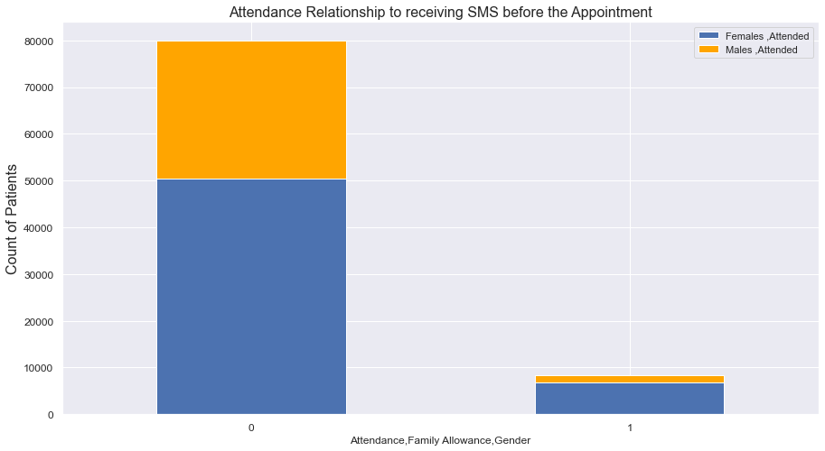

```python
FAA = df[df['Gender']=='Female'][df[df['Gender']=='Female']['Attendance'] == 'Attended'].groupby(['Attendance','Family Allowance'])['Gender'].value_counts()
FAA.plot(kind='bar',figsize=(15,8));
MAA = df[df['Gender']=='Male'][df[df['Gender']=='Male']['Attendance'] == 'Attended'].groupby(['Attendance','Family Allowance'])['Gender'].value_counts()
MAA.plot(kind='bar',figsize=(15,8), color='orange', bottom=FAA);

x = []
for i in range(len(FAA.index)):
    Attendance,Age,Gender = FAA.index[i]
    x.append(Age)

x_ticks = x
plt.ylabel('Count of Patients', fontsize=font_size1);
plt.title('Attendance Relationship to receiving SMS before the Appointment', fontsize=font_size1);
plt.xticks(fontsize= font_size2, rotation='horizontal', labels=x_ticks, ticks=np.arange(len(x)));
plt.yticks(fontsize= font_size2);
plt.legend(['Females ,Attended', 'Males ,Attended', 'Females ,Missed Appointment', 'Males ,Missed Appointment']);
```

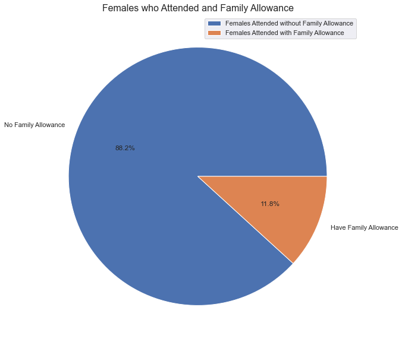

```python
FMA = df[df['Gender']=='Female'][df[df['Gender']=='Female']['Attendance'] == 'Attended'].groupby(['Attendance','Family Allowance'])['Gender'].value_counts()
FMA.plot(kind='pie',figsize=(10,10), labels=['No Family Allowance','Have Family Allowance'], autopct='%1.1f%%');

plt.ylabel('', fontsize=font_size1);
plt.title('Females who Attended and Family Allowance', fontsize=font_size1);
plt.xticks(fontsize= font_size2, rotation='horizontal');
plt.yticks(fontsize= font_size2);
plt.legend(['Females Attended without Family Allowance', 'Females Attended with Family Allowance']);
```

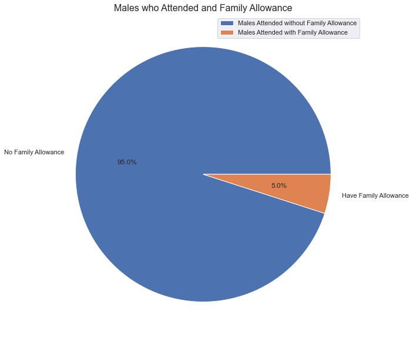

```python
FMA = df[df['Gender']=='Male'][df[df['Gender']=='Male']['Attendance'] == 'Attended'].groupby(['Attendance','Family Allowance'])['Gender'].value_counts()
FMA.plot(kind='pie',figsize=(10,10), labels=['No Family Allowance','Have Family Allowance'], autopct='%1.1f%%');

plt.ylabel('', fontsize=font_size1);
plt.title('Males who Attended and Family Allowance', fontsize=font_size1);
plt.xticks(fontsize= font_size2, rotation='horizontal');
plt.yticks(fontsize= font_size2);
plt.legend(['Males Attended without Family Allowance', 'Males Attended with Family Allowance']);
```

Here we will find that less males have family allowance than females, as 11.8% of females have family allowance but only 5% of males have it.

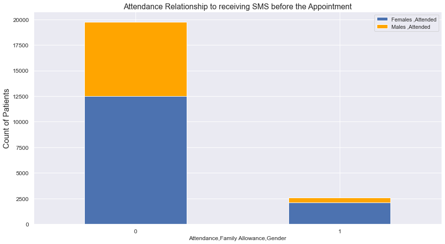

```python
FAA = df[df['Gender']=='Female'][df[df['Gender']=='Female']['Attendance'] == 'Missed Appointment'].groupby(['Attendance','Family Allowance'])['Gender'].value_counts()
FAA.plot(kind='bar',figsize=(15,8));
MAA = df[df['Gender']=='Male'][df[df['Gender']=='Male']['Attendance'] == 'Missed Appointment'].groupby(['Attendance','Family Allowance'])['Gender'].value_counts()
MAA.plot(kind='bar',figsize=(15,8), color='orange', bottom=FAA);

x = []
for i in range(len(FAA.index)):
    Attendance,Age,Gender = FAA.index[i]
    x.append(Age)

x_ticks = x
plt.ylabel('Count of Patients', fontsize=font_size1);
plt.title('Attendance Relationship to receiving SMS before the Appointment', fontsize=font_size1);
plt.xticks(fontsize= font_size2, rotation='horizontal', labels=x_ticks, ticks=np.arange(len(x)));
plt.yticks(fontsize= font_size2);
plt.legend(['Females ,Attended', 'Males ,Attended', 'Females ,Missed Appointment', 'Males ,Missed Appointment']);
```

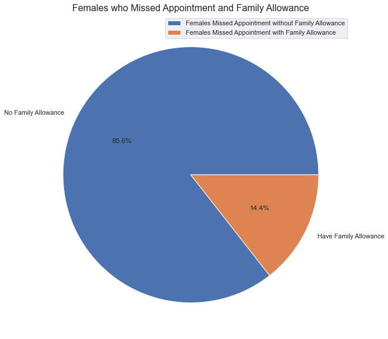

```python
FMA = df[df['Gender']=='Female'][df[df['Gender']=='Female']['Attendance'] == 'Missed Appointment'].groupby(['Attendance','Family Allowance'])['Gender'].value_counts()
FMA.plot(kind='pie',figsize=(10,10), labels=['No Family Allowance','Have Family Allowance'], autopct='%1.1f%%');

plt.ylabel('', fontsize=font_size1);
plt.title('Females who Missed Appointment and Family Allowance', fontsize=font_size1);
plt.xticks(fontsize= font_size2, rotation='horizontal');
plt.yticks(fontsize= font_size2);
plt.legend(['Females Missed Appointment without Family Allowance', 'Females Missed Appointment with Family Allowance']);
```

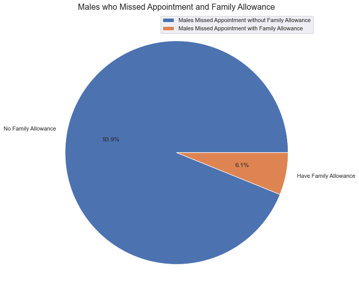

```python
MMA = df[df['Gender']=='Male'][df[df['Gender']=='Male']['Attendance'] == 'Missed Appointment'].groupby(['Attendance','Family Allowance'])['Gender'].value_counts()
MMA.plot(kind='pie',figsize=(10,10), labels=['No Family Allowance','Have Family Allowance'], autopct='%1.1f%%');

plt.ylabel('', fontsize=font_size2);
plt.title('Males who Missed Appointment and Family Allowance', fontsize=font_size1);
plt.xticks(fontsize= font_size2, rotation='horizontal');
plt.yticks(fontsize= font_size2);
plt.legend(['Males Missed Appointment without Family Allowance', 'Males Missed Appointment with Family Allowance']);
```

Here we can also find when comparing attendance and its relation to family allowance we will find that more patients who have family allowance tend to miss their appointment more than patients without it, as 5% of males attended at time but 6.1% missed the appointment, and for females 11.8% attended but 14.4% missed the appointment.

### Here you can find more Visuals

### What is the relation between Attendance and Hospitals' Locations?

```
Attendance  Hospital Location
Attended    JARDIM CAMBURI       6252
            MARIA ORTIZ          4586
            RESISTÊNCIA          3525
Name: Hospital Location, dtype: int64

 Attendance          Hospital Location
Missed Appointment  JARDIM CAMBURI       1465
                    MARIA ORTIZ          1219
                    ITARARÉ               923
Name: Hospital Location, dtype: int64
```

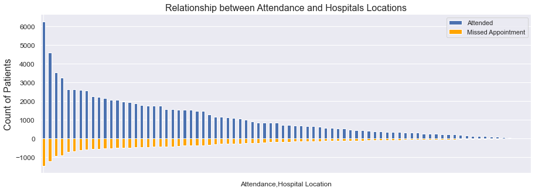

```python
Location_Attended = df[df['Attendance']=='Attended'].groupby('Attendance')['Hospital Location'].value_counts()
Location_Attended.plot(kind='bar', figsize=(15,5));
Location_Missed = df[df['Attendance']=='Missed Appointment'].groupby('Attendance')['Hospital Location'].value_counts()*(-1)
Location_Missed.plot(kind='bar', figsize=(15,5), color='orange');

plt.ylabel('Count of Patients', fontsize=font_size1);
plt.title('Relationship between Attendance and Hospitals Locations', fontsize=font_size1);
plt.xticks(fontsize= font_size2, rotation='vertical', labels=[], ticks=[0]);
plt.yticks(fontsize= font_size2)
plt.legend(['Attended', 'Missed Appointment']);

print(Location_Attended.nlargest(3),'\n'*2, (Location_Missed*(-1)).nlargest(3))
```

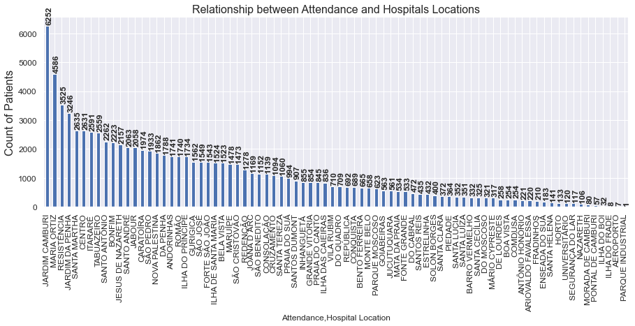

```python
Location_Attended = df[df['Attendance']=='Attended'].groupby('Attendance')['Hospital Location'].value_counts()
Location_Attended.plot(kind='bar', figsize=(15,5));

x = []
for i in range(len(Location_Attended.index)):
    Attendance,Location = Location_Attended.index[i]
    x.append(Location)

plt.ylabel('Count of Patients', fontsize=font_size1);
plt.title('Relationship between Attendance and Hospitals Locations', fontsize=font_size1);
plt.xticks(fontsize= font_size2, rotation='vertical',ticks=np.arange(len(x)), labels=x);
plt.yticks(fontsize= font_size2);

for num, value in enumerate(Location_Attended):
    plt.text(num-0.2, value+100, str(value), fontweight='bold', rotation='vertical');
```

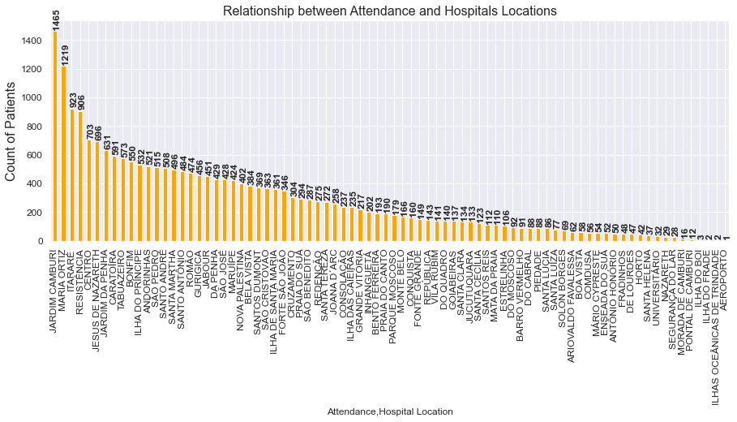

```python
Location_Missed = df[df['Attendance']=='Missed Appointment'].groupby('Attendance')['Hospital Location'].value_counts()
Location_Missed.plot(kind='bar', figsize=(15,5), color='orange');

x = []
for i in range(len(Location_Missed.index)):
    Attendance,Location = Location_Missed.index[i]
    x.append(Location)

plt.ylabel('Count of Patients', fontsize=font_size1);
plt.title('Relationship between Attendance and Hospitals Locations', fontsize=font_size1);
plt.xticks(fontsize= font_size2, rotation='vertical',ticks=np.arange(len(x)), labels=x);
plt.yticks(fontsize= font_size2);

for num, value in enumerate(Location_Missed):
    plt.text(num-0.2, value+20, str(value), fontweight='bold', rotation='vertical');
```